# Analysis summary

Gordana

2025-01-30

Load fitted models

```r
# load fitted models
load( file ="../data/derived/diab_tree")
load( file ="../data/derived/diab_lasso")
load( file ="../data/derived/diab_elastic")
```

### Table 1 (see also Table1.csv)

```r
diab_full <- read.csv("../data/clean_modsel.csv", stringsAsFactors =TRUE) %>%
  mutate(charlson = exp(lcharlson) - 1) %>%
  dplyr::select( -patient_mrn, -ID, -admit_dttm, , - represent) %>%
  relocate(readmit) %>% # put readmit in first column
  mutate(age = as.integer(age),
         bgl_min=relevel(bgl_min, ">=4"),
         med_surg = factor(med_surg, levels = 1:2, labels = c("Medical", "Surgical")),
         emergency = factor(emergency, levels = 1:2, labels = c("Emerg", "NotEmerg")),
         charlson = as.integer(charlson),
         disadvantage = as.integer(disadvantage),
         age_s = (age - 70)/10, # scaling
         disadvantage_s = (disadvantage-1000)/50,
         readmit = ifelse(readmit==1,"Yes","No")) # scaling

T1 <- table1( ~   age + sex + ethnicity + dmtypes + charlson +
                             insulin + last90days + med_surg+
                             emergency + MaritalStatus + bgl_max + bgl_min + interaction(bgl_max,bgl_min)+
                             disadvantage +  length_of_stay_days | osp_full_name +readmit  ,
              overall = FALSE,
              data=diab_full,
              render.continuous=c( .="Median [Q1, Q3]"))


T1
```

|  | Prince of Wales Hospital No (N=4921) | Prince of Wales Hospital Yes (N=329) | St George Hospital No (N=4558) | St George Hospital Yes (N=235) |
| --- | --- | --- | --- | --- |
| age |  |  |  |  |
| Median [Q1, Q3] | 73.0 [64.0, 81.0] | 77.0 [66.0, 83.0] | 75.0 [66.0, 83.0] | 77.0 [68.0, 83.0] |
| sex |  |  |  |  |
| Male | 2898 (58.9%) | 200 (60.8%) | 2645 (58.0%) | 138 (58.7%) |
| Not_Male | 2023 (41.1%) | 129 (39.2%) | 1913 (42.0%) | 97 (41.3%) |
| ethnicity |  |  |  |  |
| aust | 2253 (45.8%) | 134 (40.7%) | 1733 (38.0%) | 75 (31.9%) |
| non_english_speaking | 2231 (45.3%) | 169 (51.4%) | 2548 (55.9%) | 147 (62.6%) |
| other_english_sp | 437 (8.9%) | 26 (7.9%) | 277 (6.1%) | 13 (5.5%) |
| dmtypes |  |  |  |  |
| Type1 | 176 (3.6%) | 8 (2.4%) | 108 (2.4%) | 10 (4.3%) |
| Type2 | 4745 (96.4%) | 321 (97.6%) | 4450 (97.6%) | 225 (95.7%) |
| charlson |  |  |  |  |
| Median [Q1, Q3] | 0 [0, 2.00] | 2.00 [0, 3.00] | 0 [0, 2.00] | 2.00 [0, 3.00] |
| insulin |  |  |  |  |
| Insulin | 1272 (25.8%) | 89 (27.1%) | 1015 (22.3%) | 52 (22.1%) |
| No_insulin | 3649 (74.2%) | 240 (72.9%) | 3543 (77.7%) | 183 (77.9%) |
| last90days |  |  |  |  |
| No | 3703 (75.2%) | 178 (54.1%) | 3511 (77.0%) | 120 (51.1%) |
| Yes | 1218 (24.8%) | 151 (45.9%) | 1047 (23.0%) | 115 (48.9%) |
| med_surg |  |  |  |  |
| Medical | 2868 (58.3%) | 244 (74.2%) | 3074 (67.4%) | 183 (77.9%) |
| Surgical | 2053 (41.7%) | 85 (25.8%) | 1484 (32.6%) | 52 (22.1%) |
| emergency |  |  |  |  |
| Emerg | 3569 (72.5%) | 279 (84.8%) | 3821 (83.8%) | 214 (91.1%) |
| NotEmerg | 1352 (27.5%) | 50 (15.2%) | 737 (16.2%) | 21 (8.9%) |
| MaritalStatus |  |  |  |  |
| Married or De facto | 2526 (51.3%) | 162 (49.2%) | 2700 (59.2%) | 148 (63.0%) |
| Other | 2395 (48.7%) | 167 (50.8%) | 1858 (40.8%) | 87 (37.0%) |
| bgl_max |  |  |  |  |
| <10 | 1307 (26.6%) | 87 (26.4%) | 1332 (29.2%) | 70 (29.8%) |
| >15 | 1736 (35.3%) | 125 (38.0%) | 1493 (32.8%) | 96 (40.9%) |
| 10-15 | 1878 (38.2%) | 117 (35.6%) | 1733 (38.0%) | 69 (29.4%) |
| bgl_min |  |  |  |  |
| >=4 | 4276 (86.9%) | 267 (81.2%) | 3953 (86.7%) | 197 (83.8%) |
| <4 | 645 (13.1%) | 62 (18.8%) | 605 (13.3%) | 38 (16.2%) |
| interaction(bgl_max, bgl_min) |  |  |  |  |
| <10.>=4 | 1237 (25.1%) | 81 (24.6%) | 1237 (27.1%) | 67 (28.5%) |
| >15.>=4 | 1355 (27.5%) | 86 (26.1%) | 1145 (25.1%) | 71 (30.2%) |
| 10-15.>=4 | 1684 (34.2%) | 100 (30.4%) | 1571 (34.5%) | 59 (25.1%) |
| <10.<4 | 70 (1.4%) | 6 (1.8%) | 95 (2.1%) | 3 (1.3%) |
| >15.<4 | 381 (7.7%) | 39 (11.9%) | 348 (7.6%) | 25 (10.6%) |
| 10-15.<4 | 194 (3.9%) | 17 (5.2%) | 162 (3.6%) | 10 (4.3%) |
| disadvantage |  |  |  |  |
| Median [Q1, Q3] | 1010 [990, 1050] | 1040 [1010, 1060] | 1000 [979, 1030] | 1000 [991, 1030] |
| length_of_stay_days |  |  |  |  |
| Median [Q1, Q3] | 5.00 [2.00, 10.0] | 6.00 [3.00, 15.0] | 5.00 [2.00, 9.00] | 6.00 [3.00, 11.0] |

```r
write.csv(as.data.frame(T1), file = "../results/Table1.csv", row.names = FALSE)
```

```r
train_per <- read.csv("../data/derived/model_pred_train.csv") %>%
  mutate(data = "Training - POW 80%") %>%
  dplyr::select(AUC:UCL, model, data)
test_per <- read.csv("../data/derived/model_pred_test.csv")  %>%
  mutate(data = "Test - POW 20%")%>%
  dplyr::select(AUC:UCL, model, data)
validation_per <- read.csv("../data/derived/model_pred_validation.csv")  %>%
  mutate(data = "Validation - St George")%>%
  dplyr::select(AUC:UCL, model, data)


all_AUC <- bind_rows(train_per, test_per, validation_per)

Table2 <- all_AUC %>%
  transmute(data,
            model,
            `AUC (95% CI)` = paste0(round(AUC,3)," (",round(LCL,3),", ", round(UCL,3),")"))

Table2
```

```
##                      data    model         AUC (95% CI)
## 1      Training - POW 80%     tree 0.692 (0.665, 0.719)
## 2      Training - POW 80% gp_lasso   0.731 (0.7, 0.761)
## 3      Training - POW 80%  elastic 0.731 (0.701, 0.762)
## 4      Training - POW 80%     nnet 0.727 (0.696, 0.758)
## 5          Test - POW 20%     tree 0.663 (0.614, 0.713)
## 6          Test - POW 20% gp_lasso 0.722 (0.665, 0.779)
## 7          Test - POW 20%  elastic 0.725 (0.668, 0.781)
## 8          Test - POW 20%     nnet 0.727 (0.673, 0.781)
## 9  Validation - St George     tree  0.595 (0.56, 0.629)
## 10 Validation - St George gp_lasso 0.653 (0.616, 0.689)
## 11 Validation - St George  elastic 0.659 (0.622, 0.695)
## 12 Validation - St George     nnet 0.667 (0.631, 0.703)
```

```r
write.csv(Table2, file = "../results/Table2.csv", row.names = F)
```

```r
library(forestplot)

models = data.frame(model = c("tree", "gp_lasso","elastic","nnet"),
           model_nice = c("Classification tree", "Group Lasso","Elastic net","Neural network"))


all_AUC <- all_AUC %>%
  mutate(interval = paste0(format(round(AUC, 3), nsmall = 3), " ",
                          "(",format(round(LCL, 3), nsmall = 3), " - ",
                          format(round(UCL,3), nsmall = 3),")")) %>%
  mutate(data_single = ifelse(model == "tree", data, NA)) %>%
  left_join(models)

png("../results/AUCplot.png", width=8, height=4,units = "in",
    res = 300)


all_AUC |>
  forestplot(labeltext = c(data_single, model_nice, interval),
             mean = AUC,
             lower = LCL,
             upper = UCL,
             zero = NA,
             mar = unit(rep(5, times = 4), "mm"),
             xticks = seq(0.55,0.8, by = 0.05),
             boxsize = 0.2,
            lineheight =  unit(5,"mm"),
             xlab = "AUC (95% CI)",
             lwd.ci = 2) %>%
  fp_add_header(data_single = c("Data")|> fp_txt_plain(),
                model_nice = c("Model")|> fp_txt_plain(),
                interval = c("AUC (95% CI)")|> fp_txt_plain()) %>%
  fp_set_style(align = "lllr",
               hrz_lines = "#999999",
               txt_gp = fpTxtGp(cex=0.85,
                                ticks=gpar(cex=0.8),
                                xlab = gpar(cex = 0.8)),
               axes = gpar(cex = 0.85))



dev.off()
```

### Table 3 and 4

```r
Table3 <- all_roc %>%
  filter(selected == 1) %>%
  dplyr::select(- selected) %>%
  arrange(data, model) %>%
  mutate_if(is.numeric, ~ round(., digits = 3))




Table3 <- Table3 %>%
  arrange(desc(data))


Table3%>%
  filter(data != "Training - POW 80%") %>%
  mutate(data = substr(data, 1,10))
```

```
##     score sensitivities specificities   PPV   NPV   model       data
## 1  -2.113         0.250         0.911 0.187 0.937 elastic Test - POW
## 2  -2.422         0.500         0.821 0.186 0.952 elastic Test - POW
## 3  -2.822         0.750         0.629 0.142 0.968 elastic Test - POW
## 4  -1.887         0.250         0.923 0.211 0.938   lasso Test - POW
## 5  -2.390         0.500         0.804 0.173 0.951   lasso Test - POW
## 6  -2.940         0.750         0.608 0.136 0.967   lasso Test - POW
## 7   0.222         0.250         0.913 0.190 0.937    nnet Test - POW
## 8   0.197         0.500         0.810 0.178 0.952    nnet Test - POW
## 9   0.151         0.750         0.610 0.136 0.967    nnet Test - POW
## 10  0.668         0.025         0.962 0.051 0.923    tree Test - POW
## 11  0.520         0.662         0.639 0.131 0.958    tree Test - POW
## 12  0.239         0.975         0.168 0.088 0.988    tree Test - POW
## 13 -2.157         0.251         0.905 0.120 0.959 elastic External v
## 14 -2.536         0.502         0.737 0.089 0.966 elastic External v
## 15 -3.013         0.753         0.462 0.067 0.973 elastic External v
## 16 -1.999         0.251         0.910 0.126 0.959   lasso External v
## 17 -2.543         0.502         0.731 0.088 0.966   lasso External v
## 18 -3.206         0.753         0.435 0.064 0.972   lasso External v
## 19  0.218         0.251         0.896 0.110 0.959    nnet External v
## 20  0.183         0.502         0.744 0.092 0.967    nnet External v
## 21  0.125         0.753         0.454 0.066 0.973    nnet External v
## 22  0.668         0.030         0.972 0.052 0.951    tree External v
## 23  0.520         0.583         0.611 0.072 0.966    tree External v
## 24  0.239         0.872         0.189 0.053 0.966    tree External v
```

```r
write.csv(Table3, file = "../results/Table3.csv", row.names = F)
```

#### Proportion of patients that need to be seen

Calulation

- take all POW data (combined) and All St George data
- take score cutoffs from Table 3
- calculate what proportion of patients are greater than the cut-off from table 3, i.e. would be seen.

```r
data_with_pred_train <- read.csv(file = paste0("../data/derived/data_with_pred_train.csv" ))
data_with_pred_test <- read.csv(file = paste0("../data/derived/data_with_pred_test.csv" ))
data_with_pred_STG <- read.csv(file = paste0("../data/derived/data_with_pred_validation.csv" ))

data_with_pred_POW = bind_rows(data_with_pred_train, data_with_pred_test)


training_scores <- Table3 %>%
  filter(data == "Training - POW 80%")

training_scores$percent_patients = NA

training_scores$percent_patients[training_scores$model== "elastic"]<- with(training_scores %>% filter(model == "elastic"),
     apply(as.matrix(score), 1, function(x) mean(data_with_pred_POW$pred_elastic > x)))

training_scores$percent_patients[training_scores$model== "lasso"]<- with(training_scores %>% filter(model == "lasso"),
     apply(as.matrix(score), 1, function(x) mean(data_with_pred_POW$pred_lasso > x)))

training_scores$percent_patients[training_scores$model== "nnet"]<- with(training_scores %>% filter(model == "nnet"),
     apply(as.matrix(score), 1, function(x) mean(data_with_pred_POW$pred_nnet > x)))

training_scores$percent_patients[training_scores$model== "tree"]<- with(training_scores %>% filter(model == "tree"),
     apply(as.matrix(score), 1, function(x) mean(data_with_pred_POW$pred_tree > x)))



validation_scores <- Table3 %>%
  filter(data == "External validation - St George")
validation_scores$score = training_scores$score


validation_scores$percent_patients[validation_scores$model== "elastic"]<- with(validation_scores %>% filter(model == "elastic"),
     apply(as.matrix(score), 1, function(x) mean(data_with_pred_STG$pred_elastic > x)))

validation_scores$percent_patients[validation_scores$model== "lasso"]<- with(validation_scores %>% filter(model == "lasso"),
     apply(as.matrix(score), 1, function(x) mean(data_with_pred_STG$pred_lasso > x)))

validation_scores$percent_patients[validation_scores$model== "nnet"]<- with(validation_scores %>% filter(model == "nnet"),
     apply(as.matrix(score), 1, function(x) mean(data_with_pred_STG$pred_nnet > x)))

validation_scores$percent_patients[validation_scores$model== "tree"]<- with(validation_scores %>% filter(model == "tree"),
     apply(as.matrix(score), 1, function(x) mean(data_with_pred_STG$pred_tree > x)))


prop_screened = bind_rows(training_scores, validation_scores) %>%
  dplyr::select(data,score,sensitivities,model, percent_patients) %>%
  mutate(data = ifelse(data == "Training - POW 80%", "POW", "St George"))

prop_screened
```

```
##         data  score sensitivities   model percent_patients
## 1        POW -2.096         0.253 elastic       0.09066667
## 2        POW -2.454         0.502 elastic       0.22800000
## 3        POW -2.825         0.751 elastic       0.40876190
## 4        POW -1.911         0.253   lasso       0.08819048
## 5        POW -2.361         0.502   lasso       0.21180952
## 6        POW -2.893         0.751   lasso       0.40819048
## 7        POW  0.223         0.253    nnet       0.09047619
## 8        POW  0.198         0.502    nnet       0.21638095
## 9        POW  0.149         0.751    nnet       0.41866667
## 10       POW  0.668         0.068    tree       0.03523810
## 11       POW  0.520         0.699    tree       0.37942857
## 12       POW  0.239         0.980    tree       0.82952381
## 13 St George -2.096         0.251 elastic       0.08616733
## 14 St George -2.454         0.502 elastic       0.23137909
## 15 St George -2.825         0.753 elastic       0.42645525
## 16 St George -1.911         0.251   lasso       0.07657000
## 17 St George -2.361         0.502   lasso       0.21468809
## 18 St George -2.893         0.753   lasso       0.42103067
## 19 St George  0.223         0.251    nnet       0.08387231
## 20 St George  0.198         0.502    nnet       0.20968078
## 21 St George  0.149         0.753    nnet       0.41915293
## 22 St George  0.668         0.030    tree       0.02795744
## 23 St George  0.520         0.583    tree       0.39870645
## 24 St George  0.239         0.872    tree       0.81431254
```

```r
write.csv(prop_screened, file = "../results/Table3B.csv", row.names = F)
```

#### Tree

Note - The circles should have the probability of readmission in that group, however this plot is automatically done from the model, and has weighted sample not the raw data, so it is very overestimated. The true probabilities are below. There is no way to modify this plot in R, will need to be replotted manually in say Word, with the probabilities swapped out from below.

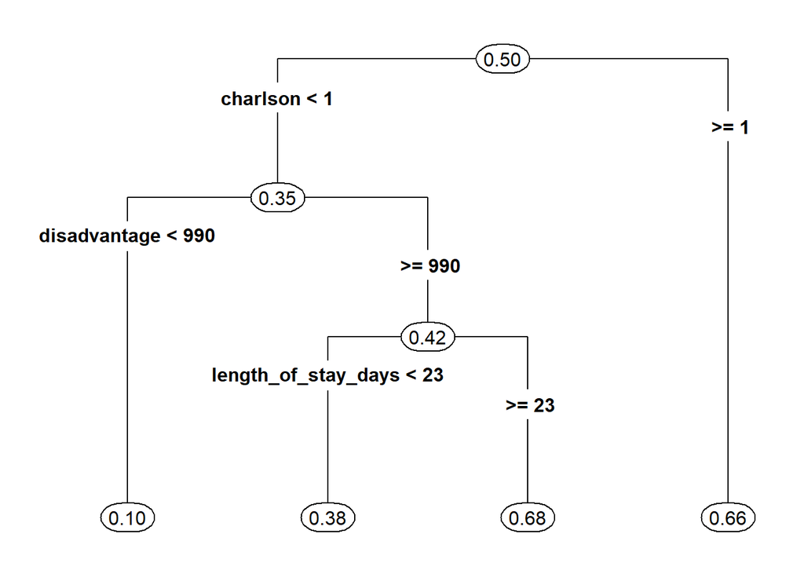

```r
load( file ="../data/derived/diab_tree")
rpart.plot(diab_tree, type=4, extra=7,box.palette=0)
```

Lookupt table for true for corrected probabilities

```r
# training
diab_train <- read.csv("../data/diabetes_clean_train.csv", stringsAsFactors =TRUE) %>%
  mutate(charlson = exp(lcharlson) - 1) %>%
  dplyr::select( -patient_mrn, -ID, -admit_dttm, -osp_full_name, - represent) %>%
  relocate(readmit) %>% # put readmit in first column
  mutate(age = as.integer(age), # for tree model
         bgl_min=relevel(bgl_min, ">=4"),
         med_surg = factor(med_surg, levels = 1:2, labels = c("Medical", "Surgical")),
         emergency = factor(emergency, levels = 1:2, labels = c("Emerg", "NotEmerg")),
         emergency = relevel(emergency, 2),
         charlson = as.integer(charlson), # for tree model
         disadvantage = as.integer(disadvantage), # for tree model
         length_of_stay_days = as.integer(length_of_stay_days),
         ethnicity = relevel(ethnicity, "aust"),
         age_s = (age - 70)/10, # scaling
         age,
         lcharlson_s = 2*(lcharlson - 0.5), # scaling
         disadvantage_s = (disadvantage-1000)/50,
         log_los_days_s = log(length_of_stay_days) - 1.5) # scaling

rel_01= table(diab_train$readmit)
w0=rel_01[2]/rel_01[1]
phat=diab_tree$frame
a=w0*phat$yval2[,5]/(1-phat$yval2[,5])
data.frame(var = phat$var,  uncorrected = round(phat$yval2[,5], 2), corrected = round(a/(1+a),2))
```

```
##                   var uncorrected corrected
## 1            charlson        0.50      0.06
## 2        disadvantage        0.35      0.03
## 3              <leaf>        0.10      0.01
## 4 length_of_stay_days        0.42      0.04
## 5              <leaf>        0.38      0.04
## 6              <leaf>        0.68      0.12
## 7              <leaf>        0.66      0.11
```

Elastic net and group lasso

```r
X <- model.matrix(~ age_s + sex + ethnicity + dmtypes + lcharlson +
                    insulin + last90days + med_surg+
                    emergency + MaritalStatus +
                    bgl_max+bgl_min + disadvantage_s + log_los_days_s,
                  data = diab_train)[,-1]



Table4 <- data.frame(gp_lasso_coef = as.matrix(coef(diab_lasso, s = "lambda.min"))[-1, 1] * apply(X, 2, sd),
                     elastic_coef = as.matrix(coef(diab_elastic, s = "lambda.min"))[-1, 1] * apply(X, 2, sd)) %>%
  transmute(`Group lasso coefficient` = round(gp_lasso_coef,3),
            `Elastic net coefficient` = round(elastic_coef,3)) %>%
  mutate(`Group lasso coefficient` = ifelse(`Group lasso coefficient` == 0, NA, `Group lasso coefficient`),
         `Elastic net coefficient` = ifelse(`Elastic net coefficient` == 0, NA, `Elastic net coefficient`)) %>%
  mutate(glasso_rank = rank(-abs(`Group lasso coefficient`)),
         elastic_rank = rank(-abs(`Elastic net coefficient`)))

Table4
```

```
##                               Group lasso coefficient Elastic net coefficient
## age_s                                           0.064                   0.068
## sexNot_Male                                        NA                      NA
## ethnicitynon_english_speaking                      NA                   0.018
## ethnicityother_english_sp                          NA                      NA
## dmtypesType2                                       NA                      NA
## lcharlson                                       0.462                   0.329
## insulinNo_insulin                                  NA                      NA
## last90daysYes                                   0.146                   0.139
## med_surgSurgical                               -0.081                  -0.074
## emergencyEmerg                                  0.090                   0.070
## MaritalStatusOther                                 NA                      NA
## bgl_max>15                                         NA                      NA
## bgl_max10-15                                       NA                      NA
## bgl_min<4                                          NA                      NA
## disadvantage_s                                  0.182                   0.118
## log_los_days_s                                  0.201                   0.136
##                               glasso_rank elastic_rank
## age_s                                   7            7
## sexNot_Male                             8            9
## ethnicitynon_english_speaking           9            8
## ethnicityother_english_sp              10           10
## dmtypesType2                           11           11
## lcharlson                               1            1
## insulinNo_insulin                      12           12
## last90daysYes                           4            2
## med_surgSurgical                        6            5
## emergencyEmerg                          5            6
## MaritalStatusOther                     13           13
## bgl_max>15                             14           14
## bgl_max10-15                           15           15
## bgl_min<4                              16           16
## disadvantage_s                          3            4
## log_los_days_s                          2            3
```

```r
write.csv(Table4, file = "../results/Table4.csv")
```

Neural net

```r
Table6 <- read.csv("../data/derived/model/var_imp_results.csv") %>%
  mutate(nnet_rank = rank(-abs(var_imp_final)))
Table6 %>%
  arrange(nnet_rank)
```

```
##     X      var_names var_imp_final nnet_rank
## 1   1      lcharlson    4.60257353         1
## 2   2 log_los_days_s    2.45034696         2
## 3   3        bgl_max    1.41764591         3
## 4   4     last90days    1.19820230         4
## 5   5 disadvantage_s    1.00767452         5
## 6   6      ethnicity    0.88458523         6
## 7   7            sex    0.80846205         7
## 8   8        insulin    0.75022963         8
## 9   9       med_surg    0.72914999         9
## 10 10          age_s    0.66710280        10
## 11 11  MaritalStatus    0.48289670        11
## 12 12        bgl_min    0.32951231        12
## 13 13      emergency    0.29556813        13
## 14 14        dmtypes    0.02390946        14
```

```r
write.csv(Table6, file = "../data/derived/Table6.csv", row.names = F)
```

tree

```r
tree_import = t(t(diab_tree$variable.importance)) %>%
  as.data.frame() %>%
  mutate(tree_rank = rank(-abs(V1))) %>%
  dplyr::select(-V1)
tree_import
```

```
##                     tree_rank
## charlson                    1
## disadvantage                2
## last90days                  3
## length_of_stay_days         4
## age                         5
## med_surg                    6
## insulin                     7
```

### Misc

#### Flagged patients

Overlap of patients with high/low BGL and those flagged for review by models

```r
data_with_pred_POW = data_with_pred_POW %>%
  mutate(bgl_lt5gt15_both = ifelse(bgl_max == ">15" & bgl_min == "<4","both","no"),
         bgl_lt5gt15_either = ifelse(bgl_max == ">15" | bgl_min == "<4","either","no"),
         osp_full_name = "Prince of Wales Hospital",
         lasso_50 = ifelse(pred_lasso>-2.361,"screen","no"),
         lasso_75 = ifelse(pred_lasso>-2.893,"screen","no"),
         lasso_25 = ifelse(pred_lasso>-1.911,"screen","no"))


with(data_with_pred_POW, table(bgl_lt5gt15_both, lasso_50))
```

```
##                 lasso_50
## bgl_lt5gt15_both   no screen
##             both  270    150
##             no   3868    962
```

```r
with(data_with_pred_POW, table(bgl_lt5gt15_either, lasso_50))
```

```
##                   lasso_50
## bgl_lt5gt15_either   no screen
##             either 1582    566
##             no     2556    546
```

```r
with(data_with_pred_POW, table(bgl_lt5gt15_both, lasso_75))
```

```
##                 lasso_75
## bgl_lt5gt15_both   no screen
##             both  191    229
##             no   2916   1914
```

```r
with(data_with_pred_POW, table(bgl_lt5gt15_either, lasso_75))
```

```
##                   lasso_75
## bgl_lt5gt15_either   no screen
##             either 1139   1009
##             no     1968   1134
```

```r
with(data_with_pred_POW, table(bgl_lt5gt15_both, lasso_25))
```

```
##                 lasso_25
## bgl_lt5gt15_both   no screen
##             both  338     82
##             no   4449    381
```

```r
with(data_with_pred_POW, table(bgl_lt5gt15_either, lasso_25))
```

```
##                   lasso_25
## bgl_lt5gt15_either   no screen
##             either 1892    256
##             no     2895    207
```

```r
with(data_with_pred_POW, prop.table(table(bgl_lt5gt15_either, readmit),margin = 1))
```

```
##                   readmit
## bgl_lt5gt15_either          0          1
##             either 0.93109870 0.06890130
##             no     0.94165055 0.05834945
```

```r
with(data_with_pred_POW, prop.table(table(lasso_50, readmit),margin = 1))
```

```
##         readmit
## lasso_50          0          1
##   no     0.96012566 0.03987434
##   screen 0.85251799 0.14748201
```

```r
with(data_with_pred_POW, prop.table(table(lasso_25, readmit),margin = 1))
```

```
##         readmit
## lasso_25          0          1
##   no     0.94861082 0.05138918
##   screen 0.82073434 0.17926566
```

```r
with(data_with_pred_POW, prop.table(table(lasso_75, readmit),margin = 1))
```

```
##         readmit
## lasso_75          0          1
##   no     0.97296427 0.02703573
##   screen 0.88567429 0.11432571
```

#### Raw coeficients for equations

```r
Table5 <- data.frame(gp_lasso_coef = as.matrix(coef(diab_lasso, s = "lambda.min"))[, 1] ,
                     elastic_coef = as.matrix(coef(diab_elastic, s = "lambda.min"))[, 1] ) %>%
  # filter(!(gp_lasso_coef == 0 & elastic_coef == 0))%>%
  rownames_to_column(var = "predictor") %>%
  pivot_longer(2:3, names_to = "model") %>%
  pivot_wider(names_from = predictor, values_from = value) %>%
  mutate(age = age_s/10,
         disadvantage = disadvantage_s/50,
         log_los_days = log_los_days_s,
         med_surgMed = -med_surgSurgical,
         sex_Male = -sexNot_Male,
         insulinInsulin  = - insulinNo_insulin ,
         Intercept = `(Intercept)`-70*age - 1000*disadvantage - 1.5*log_los_days - med_surgMed - sex_Male - insulinInsulin) %>%
  relocate(age, .before = age_s) %>%
  relocate(disadvantage, .before = disadvantage_s) %>%
  relocate(log_los_days, .before = log_los_days_s) %>%
  relocate(Intercept, .before = `(Intercept)`) %>%
  dplyr::select(-age_s, -disadvantage_s, -log_los_days_s, -`(Intercept)`, -med_surgSurgical,
                - sexNot_Male, - insulinNo_insulin)


Table5 <- t(Table5[,-1])

### calculate odds ratios here



colnames(Table5) = c('Group lasso coefficient', 'Elastic net coefficient')
Table5 <- as.data.frame(Table5) %>%
  mutate(GL_or = exp(`Group lasso coefficient`),
         EN_or = exp(`Elastic net coefficient`))

Table5
```

```
##                               Group lasso coefficient Elastic net coefficient
## Intercept                                -7.798513245            -6.264566104
## age                                       0.004812956             0.005077204
## ethnicitynon_english_speaking             0.000000000             0.036463318
## ethnicityother_english_sp                 0.000000000             0.000000000
## dmtypesType2                              0.000000000             0.000000000
## lcharlson                                 0.652019130             0.464381853
## last90daysYes                             0.332942408             0.315713627
## emergencyEmerg                            0.205439193             0.159934985
## MaritalStatusOther                        0.000000000             0.000000000
## bgl_max>15                                0.000000000             0.000000000
## bgl_max10-15                              0.000000000             0.000000000
## bgl_min<4                                 0.000000000             0.000000000
## disadvantage                              0.003363304             0.002171070
## log_los_days                              0.199142987             0.135387293
## med_surgMed                               0.165914046             0.150638809
## sex_Male                                  0.000000000             0.000000000
## insulinInsulin                            0.000000000             0.000000000
##                                      GL_or       EN_or
## Intercept                     0.0004103446 0.001902539
## age                           1.0048245572 1.005090115
## ethnicitynon_english_speaking 1.0000000000 1.037136259
## ethnicityother_english_sp     1.0000000000 1.000000000
## dmtypesType2                  1.0000000000 1.000000000
## lcharlson                     1.9194124615 1.591030394
## last90daysYes                 1.3950669513 1.371237514
## emergencyEmerg                1.2280643044 1.173434578
## MaritalStatusOther            1.0000000000 1.000000000
## bgl_max>15                    1.0000000000 1.000000000
## bgl_max10-15                  1.0000000000 1.000000000
## bgl_min<4                     1.0000000000 1.000000000
## disadvantage                  1.0033689658 1.002173429
## log_los_days                  1.2203564489 1.144980142
## med_surgMed                   1.1804716310 1.162576670
## sex_Male                      1.0000000000 1.000000000
## insulinInsulin                1.0000000000 1.000000000
```

```r
write.csv(Table5, file = "../results/Table5.csv")
```

#### Readmission rates

Per patient (based on last admission)

```r
diabetes_full <- read.csv("../data/clean_modsel.csv")


diabetes_full %>%
  group_by(osp_full_name) %>%
  summarise(patients_readmitted = mean(readmit),
            patients_represented = mean(represent))
```

```
## # A tibble: 2 × 3
##   osp_full_name            patients_readmitted patients_represented
##   <chr>                                  <dbl>                <dbl>
## 1 Prince of Wales Hospital              0.0627               0.0977
## 2 St George Hospital                    0.0490               0.0931
```

Per admission

```r
diabetes_alladmit <- read.csv("../data/clean_alladmit.csv")


diabetes_alladmit %>%
  group_by(osp_full_name) %>%
  summarise(admissions_readmitted = mean(readmit),
            admissions_represented = mean(represent))
```

```
## # A tibble: 2 × 3
##   osp_full_name            admissions_readmitted admissions_represented
##   <chr>                                    <dbl>                  <dbl>
## 1 Prince of Wales Hospital                 0.152                  0.188
## 2 St George Hospital                       0.165                  0.209
```

## References

Agresti, Alan. Categorical data analysis. Vol. 792. John Wiley & Sons, 2012.

Altmann, A., Toloşi, L., Sander, O., & Lengauer, T. (2010). Permutation importance: a corrected feature importance measure. Bioinformatics, 26(10), 1340-1347.

Terry Therneau and Beth Atkinson (2019). rpart: Recursive Partitioning and Regression Trees. R package version 4.1-15. https://CRAN.R-project.org/package=rpart

Breheny P and Huang J (2015). Group descent algorithms for nonconvex penalized linear and logistic regression models with grouped predictors. Statistics and Computing, 25: 173-187.

Schisterman, E.F., Perkins, N.J., Liu, A. and Bondell, H. (2005). Optimal cutpoint and its corresponding Youden index to discriminate individuals using pooled blood samples. Epidemiology 16, 73–81.

Jerome Friedman, Trevor Hastie, Robert Tibshirani (2010). Regularization Paths for Generalized Linear Models via Coordinate Descent. Journal of Statistical Software, 33(1), 1-22. URL http://www.jstatsoft.org/v33/i01/.

Monica Lopez-Raton, Maria Xose Rodriguez-Alvarez, Carmen Cadarso Suarez, Francisco Gude Sampedro (2014). OptimalCutpoints: An R Package for Selecting Optimal Cutpoints in Diagnostic Tests. Journal of Statistical Software, 61(8), 1-36. DOI 10.18637/jss.v061.i08.

Intrator O. and Intrator N. (1993) Using Neural Nets for Interpretation of Nonlinear Models. Proceedings of the Statistical Computing Section, 244-249 San Francisco: American Statistical Society (eds.)